# UNIVERSIDADE FEDERAL DA BAHIA INSTITUTO DE MATEMÁTICA E ESTATÍSTICA FERNANDO JEFF CAPONERO Relatório de Atividade Laboratorial #1 Salvador 2023 Disciplina: Análise de Regressão

## Apresentação

Este documento é um relatório referente a atividade de correlação e dispersão de características associadas a relação da concentração de glicose no plasma de mulheres da tribo Pina.

## Introdução

O Instituto Nacional de Diabetes e de Doenças Digestivas e Renais dos EUA conduziram um estudo com 768 mulheres da tribo Pina, que residem próximo a Phoenix. As seguintes características foram coletadas: número de gestações [pregnat], concentração de glicose no plasma (obtido duas horas depois da realização de um teste de tolerância a glicose) [glucose], pressão sanguínea diastólica (mmHg) [diastolic], largura do tríceps (mm) [triceps], nível de insulina (µU/ml) [insulin], índice de massa corpórea (kg/m2) [bmi], nível de função diabética [diabetes], idade em anos [age] e um teste para avaliação de sinais de diabetes (0 = negativo e 1 = positivo) [teste]. Na base de dados as características estão rotuladas em inglês conforme as indicações entre colchetes. Os resultados obitidos foram avaliados e contrastados entre si.

## Objetivos

1. Sumarização dos dados do estudo.
2. Verificação de observações não usuais.
3. Relação da variável resposta (diabetes) com as demais variáveis.
4. Comparação do teste com as variáveis quantitativas e os níveis de glicose e de insulina, a pressão diastólica, o tríceps, o bmi, a idade e o nível de função diabética entre aqueles que apresentaram resultados do teste positivo e negativo.

## Sumarização dos dados

Com base nos dados disponíveis no arquivo “Dados_Lab01.csv”, avaliou-se medidas de tendência central e de variabilidade além de se construir um histograma para cada uma delas, como apresentado abaixo.

**Tabela 1 - Medidas de tendência central e de variabilidade dos dados do estudo.**

|  | Mínimo | 1o Q. | Mediana | Média | 3o Q. | Máximo |
| --- | --- | --- | --- | --- | --- | --- |
| Gestações | 0.00 | 1.00 | 3.00 | 3.85 | 6.00 | 17.00 |
| Glicose | 0.00 | 99.00 | 117.00 | 120.89 | 140.25 | 199.00 |
| P. Diastólica | 0.00 | 62.00 | 72.00 | 69.11 | 80.00 | 122.00 |
| Tríceps | 0.00 | 0.00 | 23.00 | 20.54 | 32.00 | 99.00 |
| Insulina | 0.00 | 0.00 | 30.50 | 79.80 | 127.25 | 846.00 |
| IMC | 0.00 | 27.30 | 32.00 | 31.99 | 36.60 | 67.10 |
| N. Diabetes | 0.08 | 0.24 | 0.37 | 0.47 | 0.63 | 2.42 |
| Idade | 21.00 | 24.00 | 29.00 | 33.24 | 41.00 | 81.00 |

**Figura 1 - Resultado dos testes realizados nas mulheres da Tribo Pina.**

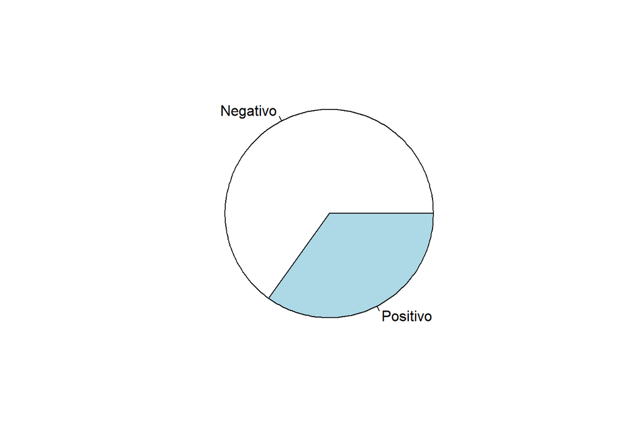

**Figura 2 - Histogramas dos dados do estudo.**

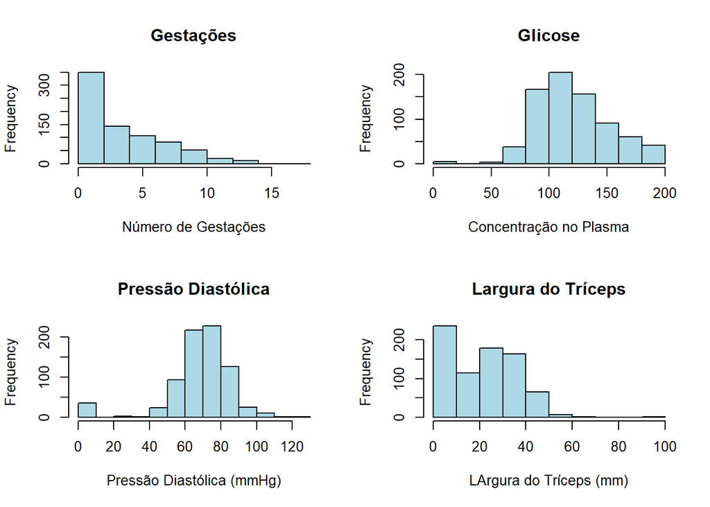

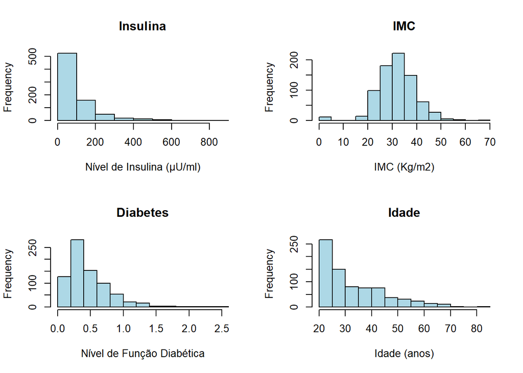

Observa-se que a presença de dados não usuais prejudicou a visualização do comportamento de algumas variáveis, como é o caso do nível de glicose no plasma, a pressão diastólica, a largura do tríceps, a concentração de insulina e o índice de massa corpórea. Fazendo-se necessário um tratamento dos dados analisados.

## Tratamento dos dados

Observou-se a presença de dados cujo valor igual a zero não corresponde a uma realidade plausível, desta forma, foram eliminados os registros com esses valores e repetidos as análise anteriores.

**Tabela 2 - Medidas de tendência central e de variabilidade dos dados do estudo sem observações não usuais.**

|  | Mínimo | 1o Q. | Mediana | Média | 3o Q. | Máximo |
| --- | --- | --- | --- | --- | --- | --- |
| Gestações | 0.00 | 1.00 | 2.00 | 3.30 | 5.00 | 17.00 |
| Glicose | 56.00 | 99.00 | 119.00 | 122.63 | 143.00 | 198.00 |
| P. Diastólica | 24.00 | 62.00 | 70.00 | 70.66 | 78.00 | 110.00 |
| Tríceps | 7.00 | 21.00 | 29.00 | 29.15 | 37.00 | 63.00 |
| Insulina | 14.00 | 76.75 | 125.50 | 156.06 | 190.00 | 846.00 |
| IMC | 18.20 | 28.40 | 33.20 | 33.09 | 37.10 | 67.10 |
| N. Diabetes | 0.09 | 0.27 | 0.45 | 0.52 | 0.69 | 2.42 |
| Idade | 21.00 | 23.00 | 27.00 | 30.86 | 36.00 | 81.00 |

**Figura 3 - Resultado dos testes realizados nas mulheres da Tribo Pina.**

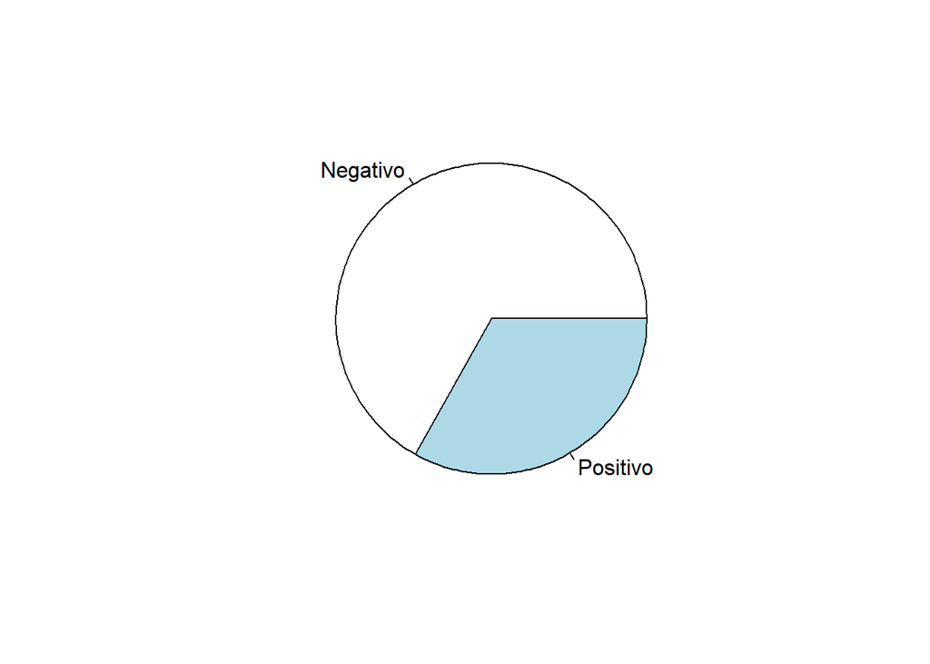

**Figura 4 - Histogramas dos dados do estudo sem observações não usuais.**

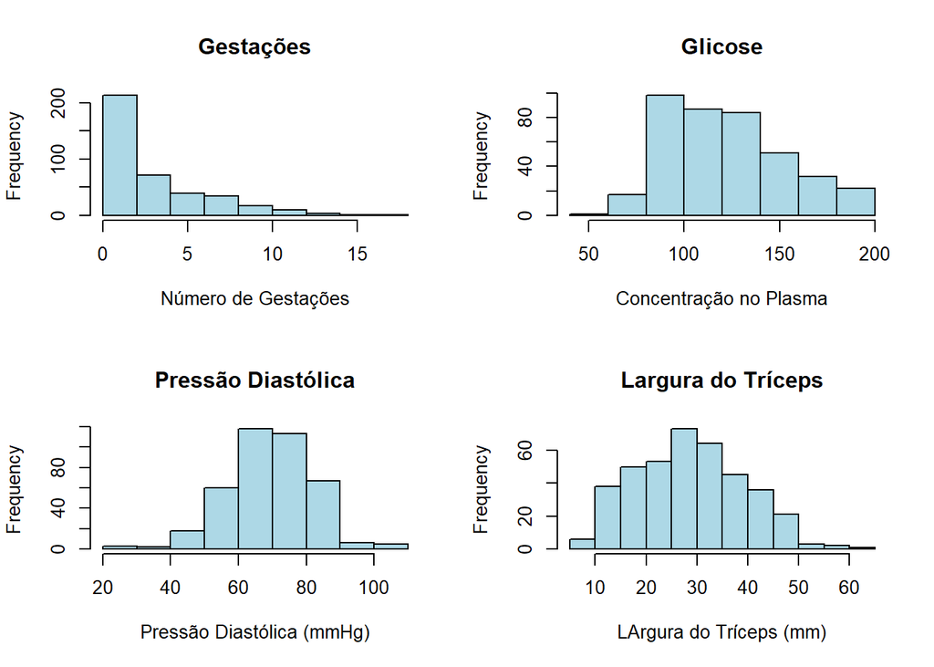

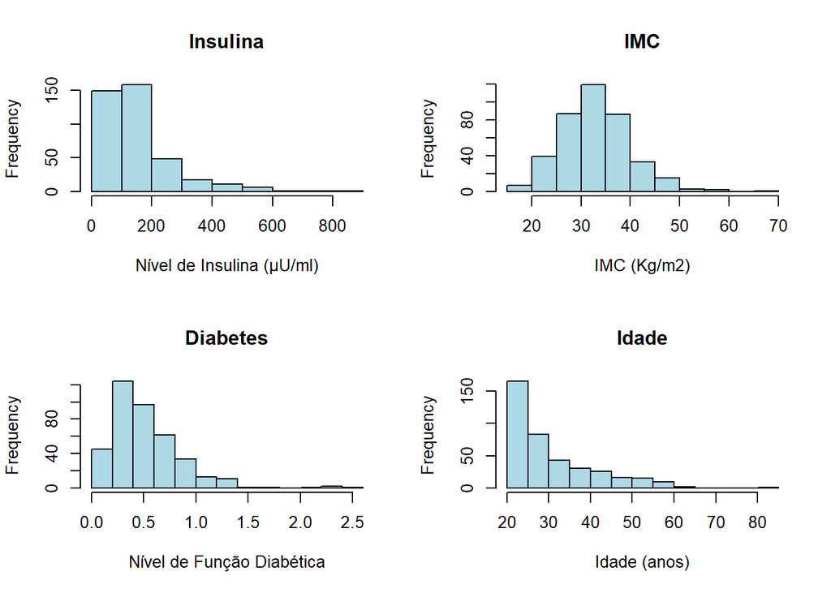

Embora a eliminação dos registros com dados faltantes tenha melhorado a a visualização do comportamento de algumas variáveis, como é o caso do nível de glicose no plasma, a pressão diastólica, a largura do tríceps, a concentração de insulina e o índice de massa corpórea; nota-se uma perda de informação para as variáveis que estavam corretamente descritas anteriormente como é o caso do número de gestações. Nota-se que o número médio foi reduzido de 3,85 para 3,30. Semelhantemente, há perda de informação para as variáveis nível de função diabética, idade e teste de sinais de diabetes.

## Relação da variável diabetes com as demais variáveis

**Figura 5 - Diagramas de dispersão da relação da variável resposta (diabetes) com as demais variáveis.**

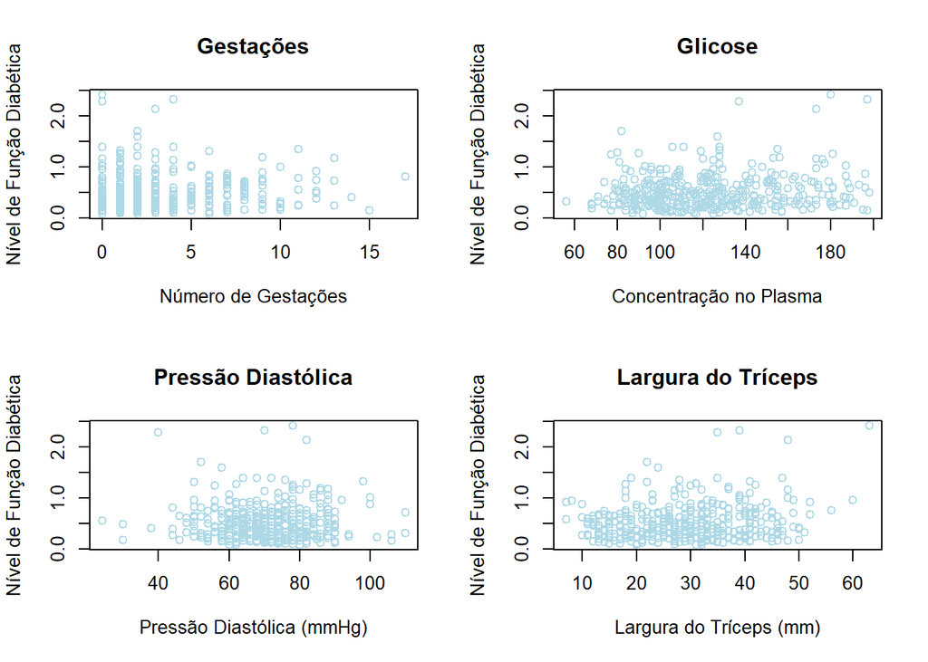

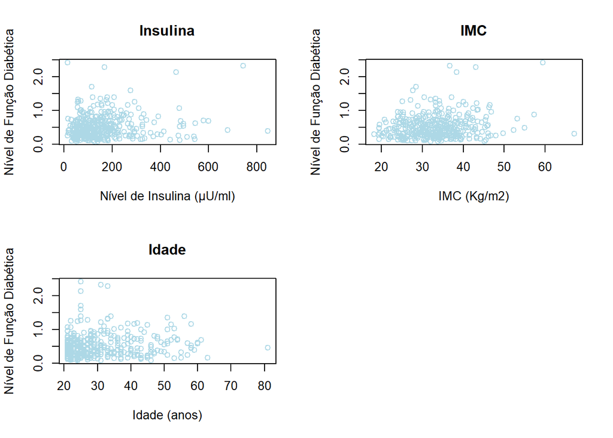

Visualmente nenhuma das características analizadas parece ter qualquer correlação com o nível de função diabética.

**Figura 6 - Boxplot do teste de sinais de diabetes com as demais variáveis.**

[figure not shown]

[figure not shown]

## Conclusão

Com base nos resutadoa analisádos, velifica-se que não parece ser suficiente a análise laboratorial na definição do estado de diabetes das mulheres da Tribo Pina. Infere-se que a análise clinica pode se valer das informações coletadas mas seu julgamento final deve contar com outras técnicas disgnósticas.

## Apêndice

### Código em linguagem R

```r
##############################################
###         Sumarização dos dados          ###
##############################################
library(knitr)
set.seed(7)
setwd("~/Dropbox/Estatística/2023.1/Regressão/Exercícios")
dados = read.csv("Dados_Lab01.csv", sep = ";")
tab.gest = summary(dados$pregnant)
tab.gluc = summary(dados$glucose)
tab.dias = summary(dados$diastolic)
tab.tric = summary(dados$triceps)
tab.insu = summary(dados$insulin)
tab.bmi = summary(dados$bmi)
tab.diab = summary(dados$diabetes)
tab.age = summary(dados$age)

tab = rbind(tab.gest,tab.gluc, tab.dias, tab.tric, tab.insu, tab.bmi, tab.diab, tab.age)

colnames(tab) = c("Mínimo", "1o Q.", "Mediana", "Média", "3o Q.", "Máximo")
rownames(tab) = c("Gestações", "Glicose", "P. Diastólica", "Tríceps", "Insulina", "IMC", "N. Diabetes", "Idade")

kable(round(tab,2))

# Plot the chart.
tab.test = table(dados$test)
rownames(tab.test) = c("Negativo", "Positivo")
pie(tab.test)

par(mfrow = c(2,2))
hist(dados$pregnant,col= "lightblue", breaks = 10, main = "Gestações", xlab = "Número de Gestações")
hist(dados$glucose,col= "lightblue", breaks = 10, main = "Glicose", xlab = "Concentração no Plasma")

hist(dados$diastolic,col= "lightblue", breaks = 10, main = "Pressão Diastólica", xlab = "Pressão Diastólica (mmHg)")
hist(dados$triceps,col= "lightblue", breaks = 10, main = "Largura do Tríceps", xlab = "LArgura do Tríceps (mm)")

hist(dados$insulin,col= "lightblue", breaks = 10, main = "Insulina", xlab = "Nível de Insulina (µU/ml)")
hist(dados$bmi,col= "lightblue", breaks = 10, main = "IMC",
     xlab = "IMC (Kg/m2)")

hist(dados$diabetes,col= "lightblue", breaks = 10, main = "Diabetes", xlab = "Nível de Função Diabética")
hist(dados$age,col= "lightblue", breaks = 10, main = "Idade", xlab = "Idade (anos)")

##############################################
###          Tratamento dos dados          ###
##############################################
library(dplyr)
dados = dados %>% filter(glucose != 0)
dados = dados %>% filter(diastolic != 0)
dados = dados %>% filter(triceps != 0)
dados = dados %>% filter(insulin != 0)
dados = dados %>% filter(bmi != 0)
dados = dados %>% filter(diabetes != 0)
dados = dados %>% filter(age != 0)


tab.gest = summary(dados$pregnant)
tab.gluc = summary(dados$glucose)
tab.dias = summary(dados$diastolic)
tab.tric = summary(dados$triceps)
tab.insu = summary(dados$insulin)
tab.bmi = summary(dados$bmi)
tab.diab = summary(dados$diabetes)
tab.age = summary(dados$age)

tab = rbind(tab.gest,tab.gluc, tab.dias, tab.tric, tab.insu, tab.bmi, tab.diab, tab.age)

colnames(tab) = c("Mínimo", "1o Q.", "Mediana", "Média", "3o Q.", "Máximo")
rownames(tab) = c("Gestações", "Glicose", "P. Diastólica", "Tríceps", "Insulina", "IMC", "N. Diabetes", "Idade")

kable(round(tab,2))

# Plot the chart.
tab.test = table(dados$test)
rownames(tab.test) = c("Negativo", "Positivo")
pie(tab.test)

par(mfrow = c(2,2))
hist(dados$pregnant,col= "lightblue", breaks = 10, main = "Gestações", xlab = "Número de Gestações")
hist(dados$glucose,col= "lightblue", breaks = 10, main = "Glicose", xlab = "Concentração no Plasma")

hist(dados$diastolic,col= "lightblue", breaks = 10, main = "Pressão Diastólica", xlab = "Pressão Diastólica (mmHg)")
hist(dados$triceps,col= "lightblue", breaks = 10, main = "Largura do Tríceps", xlab = "LArgura do Tríceps (mm)")

hist(dados$insulin,col= "lightblue", breaks = 10, main = "Insulina", xlab = "Nível de Insulina (µU/ml)")
hist(dados$bmi,col= "lightblue", breaks = 10, main = "IMC",
     xlab = "IMC (Kg/m2)")

hist(dados$diabetes,col= "lightblue", breaks = 10, main = "Diabetes", xlab = "Nível de Função Diabética")
hist(dados$age,col= "lightblue", breaks = 10, main = "Idade", xlab = "Idade (anos)")



##############################################
###          Diagramas de Dispersão        ###
##############################################

par(mfrow = c(2,2))
plot(dados$pregnant, dados$diabetes,   col= "lightblue", main = "Gestações", xlab = "Número de Gestações", ylab = "Nível de Função Diabética")
plot(dados$glucose, dados$diabetes, col= "lightblue", main = "Glicose", xlab = "Concentração no Plasma", ylab = "Nível de Função Diabética")

plot(dados$diastolic, dados$diabetes, col= "lightblue", main = "Pressão Diastólica", xlab = "Pressão Diastólica (mmHg)", ylab = "Nível de Função Diabética")
plot(dados$triceps, dados$diabetes, col= "lightblue", main = "Largura do Tríceps", xlab = "Largura do Tríceps (mm)", ylab = "Nível de Função Diabética")

plot(dados$insulin, dados$diabetes, col= "lightblue", main = "Insulina", xlab = "Nível de Insulina (µU/ml)", ylab = "Nível de Função Diabética")
plot(dados$bmi, dados$diabetes, col= "lightblue", main = "IMC",
     xlab = "IMC (Kg/m2)", ylab = "Nível de Função Diabética")

plot(dados$age, dados$diabetes, col= "lightblue", main = "Idade", xlab = "Idade (anos)", ylab = "Nível de Função Diabética")

##############################################
###          Boxplot  dos Testes           ###
##############################################

par(mfrow = c(2,2))
boxplot(dados$pregnant ~ dados$test, col= "lightblue", main = "Gestações", ylab = "Número de Gestações", xlab = "Teste de Sinais de Diabetes")
boxplot(dados$glucose ~ dados$test, col= "lightblue", main = "Gestações", ylab = "Concentração no Plasma", xlab = "Teste de Sinais de Diabetes")

boxplot(dados$diastolic ~ dados$test, col= "lightblue", main = "Gestações", ylab = "Pressão Diastólica (mmHg)", xlab = "Teste de Sinais de Diabetes")
boxplot(dados$triceps ~ dados$test,col= "lightblue", main = "Gestações", ylab = "Largura do Tríceps (mm)", xlab = "Teste de Sinais de Diabetes")

boxplot(dados$insulin ~ dados$test,col= "lightblue", main = "Gestações", ylab = "Nível de Insulina (µU/ml)", xlab = "Teste de Sinais de Diabetes")
boxplot(dados$bmi ~ dados$test,col= "lightblue", main = "Gestações", ylab = "IMC (Kg/m2)", xlab = "Teste de Sinais de Diabetes")

boxplot(dados$diabetes ~ dados$test,col= "lightblue", main = "Gestações", ylab = "Nível de Função Diabética", xlab = "Teste de Sinais de Diabetes")
boxplot(dados$age ~ dados$test,col= "lightblue", main = "Gestações", ylab = "Idade (anos)", xlab = "Teste de Sinais de Diabetes")
```